```python
import dependencies
import numpy as np

from IPython.display import display, HTML

from hvac.components import Radiator
from nummath import graphing

%matplotlib inline
```

# Radiatorkarakteristiek

De radiatorkarakteristiek is een grafiek die het verband weergeeft tussen het volumedebiet door de radiator en de warmteafgifte van de radiator, beide uitgedrukt in procenten van hun resp. maximale waarde, bij een gegeven wateraanvoertemperatuur en een gegeven ruimtetemperatuur. De maximale waarde van het volumedebiet kan het nominaal volumedebiet van de radiator zijn, die volgt uit de nominale specificaties, of het ontwerpdebiet dat vereist is voor de ontwerpbelasting van de ruimte waarin de radiator geplaatst wordt. Algemeen beschouwd is de maximale waarde van het volumedebiet dat volumedebiet dat door de radiator stroomt wanneer het radiatorventiel volledig openstaat.

**Definieer de radiator met de nominale specificaties**

```python
radiator = Radiator(
    Qe_nom=2514.0,
    Twe_nom=75.0,
    Twl_nom=65.0,
    Tr_nom=20.0,
    n=1.3473
)
```

**Geef het procentueel bereik van het volumedebiet verwarmingswater door de radiator op**  
We geven op dat een volumedebiet van 100 % overeenstemt met het volumedebiet dat volgt uit de nominale specificaties van de radiator.

```python
Vw_percent = np.linspace(0.0, 100.0, endpoint=True)
radiator.Vw = radiator.nominal_specs['Vw']  # 100 % volumedebiet (radiatorventiel volledig geopend) = nominaal volumedebiet
```

### A. Bepaal de radiatorkarakteristieken voor een reeks van wateraanvoertemperaturen (ruimtetemperatuur constant)

We laten het programma voor een reeks van volumedebieten tussen 0% en 100% van het opgegeven nominaal volumedebiet berekenen welk warmtevermogen in procenten de radiator zal afgeven bij een reeks van verschillende wateraanvoertemperaturen en een constante ruimtetemperatuur.

```python
# reeks van wateraanvoertemperaturen
Twe_list = [75.0, 80.0, 85.0, 90.0]

# constante ruimtetemperatuur
radiator.Tr = 20.0

# berekening van de radiatorkarakteristieken voor de opgegeven reeks van wateraanvoertemperaturen
Qe_list = [None] * len(Twe_list)
for i in range(len(Twe_list)):
    radiator.Twe = Twe_list[i]
    Qe_list[i] = radiator.characteristic(Vw_percent)
```

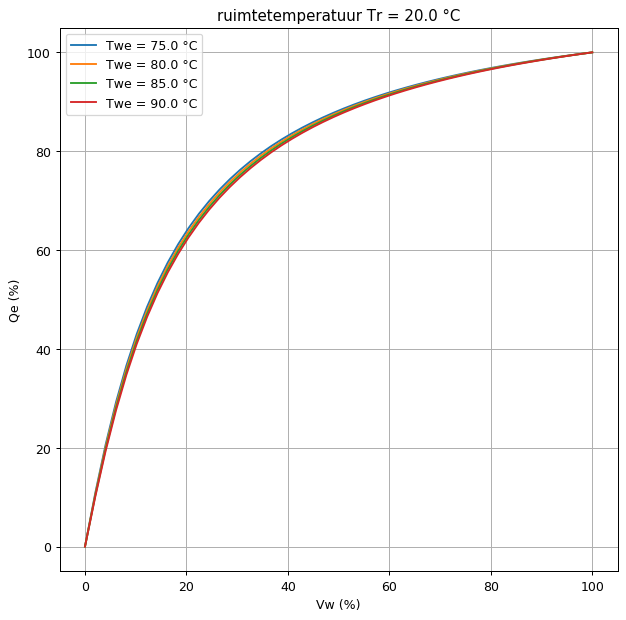

```python
graph = graphing.Graph(fig_size=[8.0, 8.0], dpi=90)
for i in range(len(Twe_list)):
    graph.add_data_set(f'Twe = {Twe_list[i]:.1f} °C', Vw_percent, Qe_list[i][0])
graph.add_legend()
graph.set_graph_title(f'ruimtetemperatuur Tr = {radiator.Tr:.1f} °C')
graph.set_axis_titles('Vw (%)', 'Qe (%)')
graph.turn_grid_on()
graph.draw_graph()
graph.show_graph()
```

Vervolgens kunnen we aan het programma vragen welke absolute waarde van het warmtevermogen overeenstemt met een warmteafgifte van 100%

```python
for i in range(len(Twe_list)):
    display(HTML(f"100 % warmteafgifte van de radiator bij wateraanvoertemperatuur {Twe_list[i]:.1f} °C = <b>{Qe_list[i][1]:.1f}</b> W"))
```

100 % warmteafgifte van de radiator bij wateraanvoertemperatuur 75.0 °C = **2514.0** W

100 % warmteafgifte van de radiator bij wateraanvoertemperatuur 80.0 °C = **2815.4** W

100 % warmteafgifte van de radiator bij wateraanvoertemperatuur 85.0 °C = **3124.2** W

100 % warmteafgifte van de radiator bij wateraanvoertemperatuur 90.0 °C = **3439.9** W

### B. Bepaal de radiatorkarakteristieken voor een reeks van ruimtetemperaturen (wateraanvoertemperatuur constant)

```python
# constante wateraanvoertemperatuur
radiator.Twe = 75.0

# reeks van ruimtetemperaturen
Tr_list = [20.0, 21.0, 22.0]

# berekening van de radiatorkarakteristieken voor de opgegeven reeks van ruimtetemperaturen
Qe_list = [None] * len(Tr_list)
for i in range(len(Tr_list)):
    radiator.Tr = Tr_list[i]
    Qe_list[i] = radiator.characteristic(Vw_percent)
```

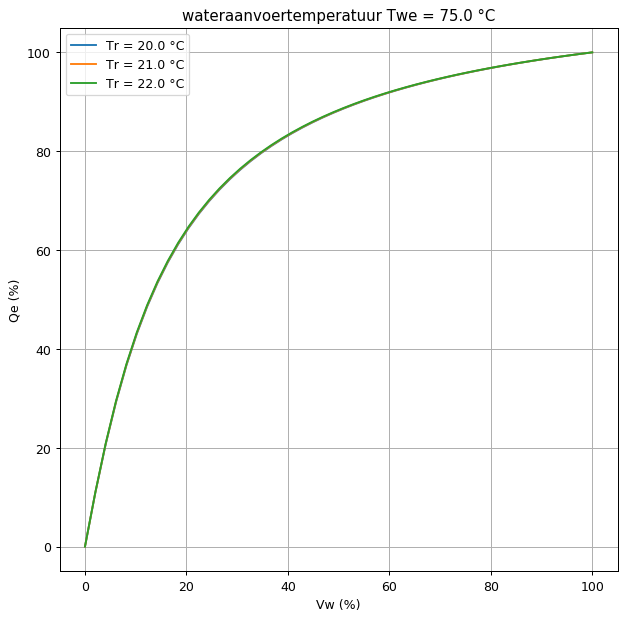

```python
graph = graphing.Graph(fig_size=[8.0, 8.0], dpi=90)
for i in range(len(Tr_list)):
    graph.add_data_set(f'Tr = {Tr_list[i]:.1f} °C', Vw_percent, Qe_list[i][0])
graph.add_legend()
graph.set_graph_title(f'wateraanvoertemperatuur Twe = {radiator.Twe:.1f} °C')
graph.set_axis_titles('Vw (%)', 'Qe (%)')
graph.turn_grid_on()
graph.draw_graph()
graph.show_graph()
```

Vervolgens kunnen we aan het programma vragen welke absolute waarde van het warmtevermogen overeenstemt met een warmteafgifte van 100%

```python
for i in range(len(Tr_list)):
    display(HTML(f"100 % warmteafgifte van de radiator bij ruimtetemperatuur {Tr_list[i]:.1f} °C = <b>{Qe_list[i][1]:.1f}</b> W"))
```

100 % warmteafgifte van de radiator bij ruimtetemperatuur 20.0 °C = **2514.0** W

100 % warmteafgifte van de radiator bij ruimtetemperatuur 21.0 °C = **2454.6** W

100 % warmteafgifte van de radiator bij ruimtetemperatuur 22.0 °C = **2395.6** W